# Geodesics

A **geodesic** is the shortest path between two points on the surface of an ellipsoid – the curved-surface equivalent of a straight line. On a flat map (equirectangular projection), geodesics appear as curves because the map distorts the ellipsoid’s geometry.

## Distance

GeodeticOps provides two distance functions:

| Function | Method | Accuracy | Speed |
| --- | --- | --- | --- |
| `haversine` | Great-circle on a sphere | ~0.5% | Fast |
| `distance` | Vincenty on the ellipsoid | ~0.5 mm | Iterative |

```julia
nyc = LLA(-74.006, 40.7128)
london = LLA(-0.1278, 51.5074)

h = haversine(nyc, london)
v = distance(nyc, london)

println("Haversine: $(round(h / 1000, digits=1)) km")
println("Vincenty:  $(round(v / 1000, digits=1)) km")
println("Difference: $(round(abs(h - v) / 1000, digits=1)) km ($(round(abs(h - v) / v * 100, digits=2))%)")
```

```
Haversine: 5570.2 km
Vincenty:  5585.2 km
Difference: 15.0 km (0.27%)
```

For most applications, the difference is negligible. Use `distance` (Vincenty) when sub-kilometer accuracy matters.

## Bearing

The **bearing** (or forward azimuth) is the initial direction of travel, measured in degrees clockwise from north:

```julia
bearing(nyc, london)
```

```
51.24122911946578
```

`forward_azimuth` is an alias for `bearing`.

## The Inverse Problem

`vincenty_inverse` returns the full solution to the inverse geodesic problem – distance plus both azimuths:

```julia
vincenty_inverse(nyc, london)
```

```
(distance = 5.585233578943206e6, azimuth1 = 51.24122911946578, azimuth2 = 288.3689981132953)
```

## The Forward Problem

Given a starting point, bearing, and distance, `forward_geodesic` computes the destination:

```julia
# 500 km northeast from NYC
forward_geodesic(nyc, 45.0, 500_000.0)
```

```
LLA(lon=-69.61180718365085°, lat=43.81439479626134°, alt=0.0m)
```

The plot below shows destinations at every 15 degrees of bearing from a point at 45 deg N. Notice the asymmetry: east/west destinations span more longitude than north/south destinations span latitude, because meridians converge toward the poles.

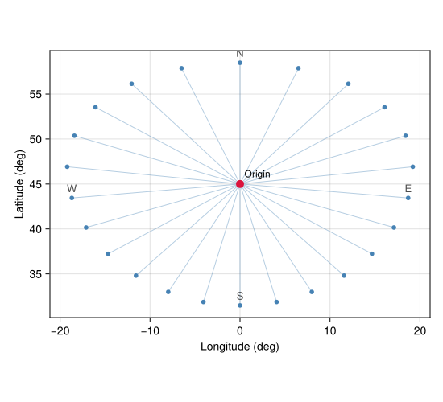

Figure 4.1: Destinations 1500 km from 45 deg N, 0 deg E at bearings 0 deg through 345 deg. The asymmetry reflects meridian convergence at higher latitudes.

```julia
origin = LLA(0.0, 45.0)
dist = 1_500_000.0
bearings_deg = 0:15:345
dests = [forward_geodesic(origin, az, dist) for az in bearings_deg]

fig = Figure(size=(550, 500))
ax = Axis(fig[1, 1], xlabel="Longitude (deg)", ylabel="Latitude (deg)", aspect=DataAspect())
for d in dests
    lines!(ax, [origin.lon, d.lon], [origin.lat, d.lat], color=(:steelblue, 0.4), linewidth=1)
end
scatter!(ax, [d.lon for d in dests], [d.lat for d in dests], color=:steelblue, markersize=8)
scatter!(ax, [origin.lon], [origin.lat], color=:crimson, markersize=14)
text!(ax, origin.lon + 0.5, origin.lat + 0.5; text="Origin", fontsize=12, align=(:left, :bottom))

# Label cardinal directions
for (az, label) in [(0, "N"), (90, "E"), (180, "S"), (270, "W")]
    d = forward_geodesic(origin, Float64(az), dist)
    text!(ax, d.lon, d.lat; text=label, fontsize=13, align=(:center, :center),
        color=:gray30, offset=(0, 12))
end
fig
```

## Interpolation

`intermediate_point` returns the point at a given fraction along the geodesic. `midpoint` is a shortcut for fraction = 0.5.

```julia
tokyo = LLA(139.6917, 35.6895)

midpoint(nyc, tokyo)
```

```
LLA(lon=-153.64271957455668°, lat=69.72196141701565°, alt=0.0m)
```

```julia
# Points at 0%, 25%, 50%, 75%, 100%
for f in 0.0:0.25:1.0
    p = intermediate_point(nyc, london, f)
    println("f=$f: $p")
end
```

```
f=0.0: LLA(lon=-74.006°, lat=40.7128°, alt=0.0m)
f=0.25: LLA(lon=-59.4518518641905°, lat=47.72478882322425°, alt=0.0m)
f=0.5: LLA(lon=-41.27790142901274°, lat=52.3894744727656°, alt=0.0m)
f=0.75: LLA(lon=-20.491869592369756°, lat=53.77005735563994°, alt=0.0m)
f=1.0: LLA(lon=-0.12780000011453324°, lat=51.507400000012495°, alt=0.0m)
```

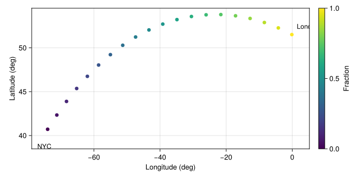

Figure 4.2: Twenty evenly-spaced intermediate points along the geodesic from New York City to London. Color indicates fraction along the path.

```julia
fracs = range(0, 1, 20)
pts = [intermediate_point(nyc, london, f) for f in fracs]
lons = [p.lon for p in pts]
lats = [p.lat for p in pts]

fig = Figure(size=(700, 350))
ax = Axis(fig[1, 1], xlabel="Longitude (deg)", ylabel="Latitude (deg)")
scatter!(ax, lons, lats, color=collect(fracs), colormap=:viridis, markersize=10)
Colorbar(fig[1, 2], colormap=:viridis, limits=(0, 1), label="Fraction")
text!(ax, lons[1] - 1, lats[1] - 1.5; text="NYC", fontsize=13, align=(:center, :top))
text!(ax, lons[end] + 1.5, lats[end] + 0.5; text="London", fontsize=13, align=(:left, :bottom))
fig
```

## Geodesic vs. Rhumb Line

A **rhumb line** (loxodrome) crosses all meridians at the same angle – it appears as a straight line on a Mercator map. A geodesic is shorter but changes bearing continuously.

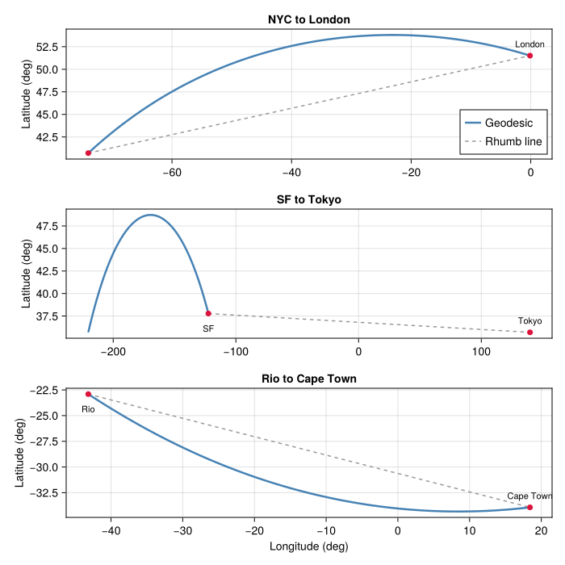

Figure 4.3: Geodesic (blue) versus rhumb line (gray dashed) for three city pairs. The geodesic always curves toward the nearer pole.

```julia
pairs = [
    (LLA(-74.006, 40.7128), LLA(-0.1278, 51.5074), "NYC", "London"),
    (LLA(-122.4194, 37.7749), LLA(139.6917, 35.6895), "SF", "Tokyo"),
    (LLA(-43.1729, -22.9068), LLA(18.4241, -33.9249), "Rio", "Cape Town"),
]

fig = Figure(size=(700, 700))
for (i, (a, b, name_a, name_b)) in enumerate(pairs)
    ax = Axis(fig[i, 1], xlabel= i == 3 ? "Longitude (deg)" : "", ylabel="Latitude (deg)",
        title="$name_a to $name_b")

    # Geodesic
    n = 100
    geo = [intermediate_point(a, b, f) for f in range(0, 1, n)]
    lines!(ax, [p.lon for p in geo], [p.lat for p in geo], color=:steelblue, linewidth=2.5, label="Geodesic")

    # Rhumb line
    lines!(ax, collect(range(a.lon, b.lon, n)), collect(range(a.lat, b.lat, n)),
        color=:gray60, linewidth=1.5, linestyle=:dash, label="Rhumb line")

    scatter!(ax, [a.lon, b.lon], [a.lat, b.lat], color=:crimson, markersize=10)
    text!(ax, a.lon, a.lat; text=name_a, fontsize=11, offset=(0, -12), align=(:center, :top))
    text!(ax, b.lon, b.lat; text=name_b, fontsize=11, offset=(0, 8), align=(:center, :bottom))

    i == 1 && axislegend(ax, position=:rb)
end
fig
```